# TiersAnalysis

Henry Hyde

2023-12-23

# Research Q:

```
To what degree do the variety of property revaluation cycles affect county distress rankings

Preliminary Answer: Little
```

# Exploration of County Tiers Generally

Tier are four elements that determine a County’s Tier, aka its Distress Rank

1. Per Capita Taxible Property Value
2. Per Capita Taxible Income
3. Population Growth Rate
4. Unemployment Rate

Each County is ranked from 1-100 on each of these elements, the sum of each County’s four rankings are then ranked to determine the County’s overall Distress Rank. The Fourty ‘Most Distressed’ Counties are those fourty with the lowest Distress Rank, these fourty are Called Tier-1 Counties. The Counties with Distress Rankings of 41-80 are called Tier-2 Counties. The Counties with Distress Rankings of 81-100 are called Tier-3 Counties.

*All data is derived from the NC Department of Commerce Website and represents the six years of data since the formula change of 2018*

## What is the importance of one’s County Tier?

A Counties Tier determines its elegibility for certain state programs, for others it does not affect its elegibility but it does determine the level of local ‘match’ for projects.

## 1. Per Capita Taxible Property Value

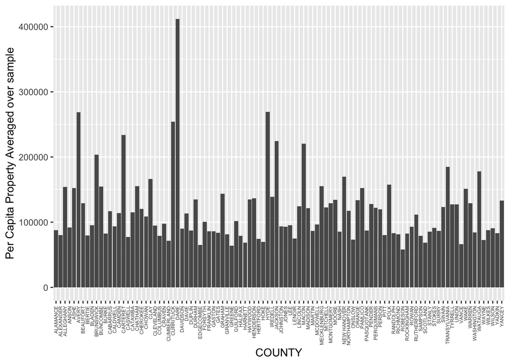

```r
#Prop Value
TiersDF %>%
  group_by(COUNTY) %>%
  summarize(AverageProp = mean(AdjustedProperty)) %>%
  ggplot(aes(COUNTY, AverageProp))+
  geom_col()+
  ylab("Per Capita Property Averaged over sample")+
  theme(axis.text.x = element_text(angle = 90, vjust = 0.5, hjust=1, size = 5))
```

## 2. Per Capita Taxible Income

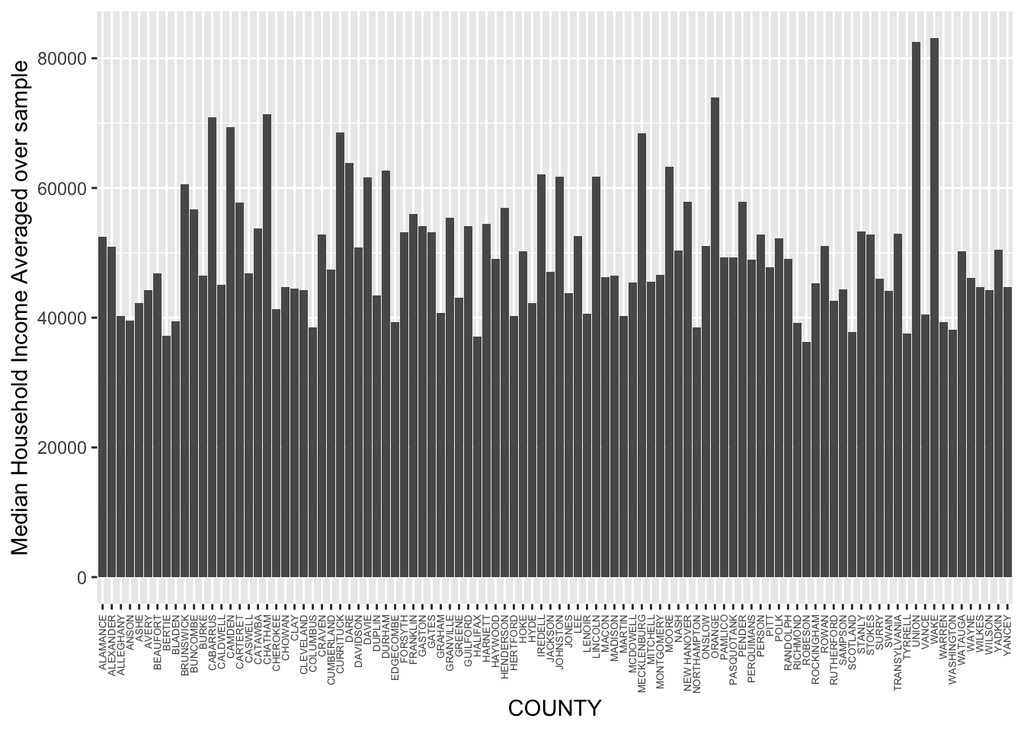

```r
##Average Income
TiersDF %>%
  group_by(COUNTY) %>%
  summarise(AverageInc = mean(Median.Household.Income)) %>%
  ggplot(aes(COUNTY, AverageInc))+
    geom_col()+
    ylab("Median Household Income Averaged over sample")+
    theme(axis.text.x = element_text(angle = 90, vjust = 0.5, hjust=1, size = 5))
```

## 3. Population Growth Rate

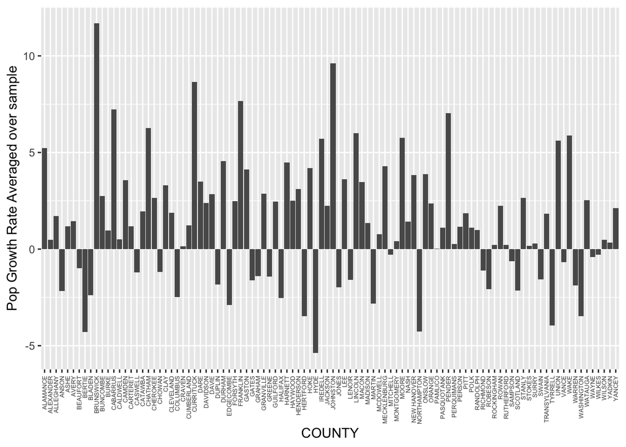

```r
##Averaged Population Growth
TiersDF %>%
  group_by(COUNTY) %>%
  summarise(AverageGrowth = mean(Population.Growth)) %>%
  ggplot(aes(COUNTY, AverageGrowth))+
  geom_col()+
  ylab("Pop Growth Rate Averaged over sample")+
  theme(axis.text.x = element_text(angle = 90, vjust = 0.5, hjust=1, size = 5))
```

## 4. Unemployment Rate

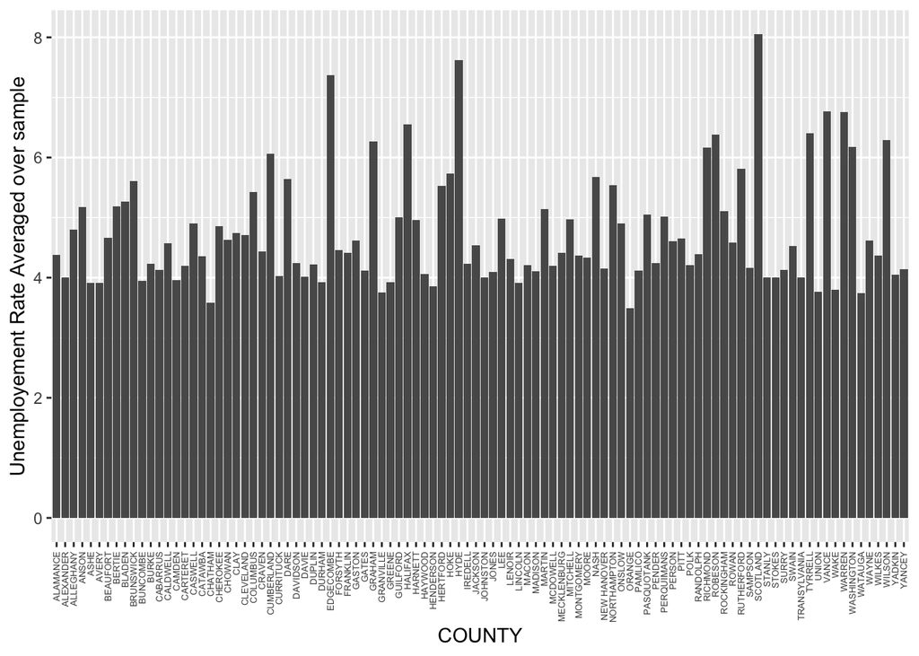

```r
##Averaged Unemp
TiersDF %>%
  group_by(COUNTY) %>%
  summarise(AveUnemp = mean(Unemployment)) %>%
  ggplot(aes(COUNTY, AveUnemp))+
  geom_col()+
  ylab("Unemployement Rate Averaged over sample")+
  theme(axis.text.x = element_text(angle = 90, vjust = 0.5, hjust=1, size = 5))
```

# Background:

What are the revaluation cycles?

NCGS 105-286 requires every county to perform a countywide revaluation at least every 8 years. Many counties, however, do it much more frequently. (Burke is on a four year cycle, last completed in 2023)

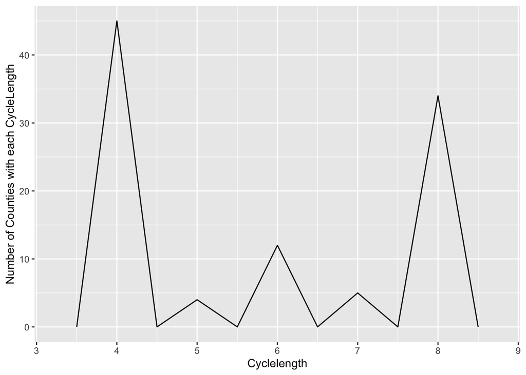

```r
#########PROPERTY
##Cycle Length
CycleLength <- TiersDF %>%
  group_by(COUNTY) %>%
  summarise(Cyclelength = (mean(NextReval)) - (mean(LatestReval)))

CycleLength %>%
  group_by(Cyclelength) %>%
  ggplot(aes(Cyclelength))+
  geom_freqpoly(binwidth = .5)+
  ylab("Number of Counties with each CycleLength")
```

FYI: The average Cycle Lenth is 5.79

# Corelation

There is not as much correlation as expected between a revaluation and property value. In Burke’s case, the slope is lower between the year prior to revaluation and the year of revaluation (2023), than between two years prior and one

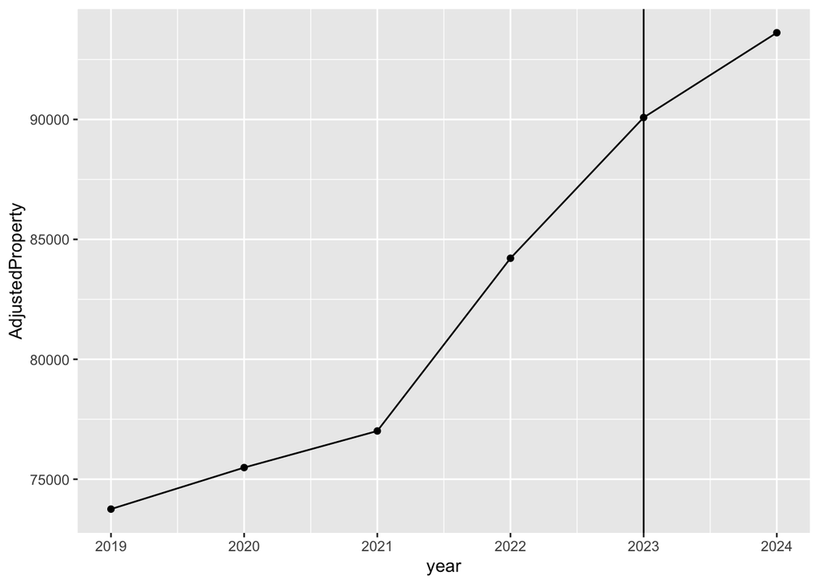

```r
##Burke's Graph
BurkeDF <- TiersDF %>%
  filter(COUNTY == "BURKE")
BurkeDF %>%
  ggplot(aes(year, AdjustedProperty))+
  geom_line()+
  geom_point()+
  geom_vline(data = BurkeDF, aes(xintercept = LatestReval))
```

## All Counties with Revaluations in Recent Years Overlaid

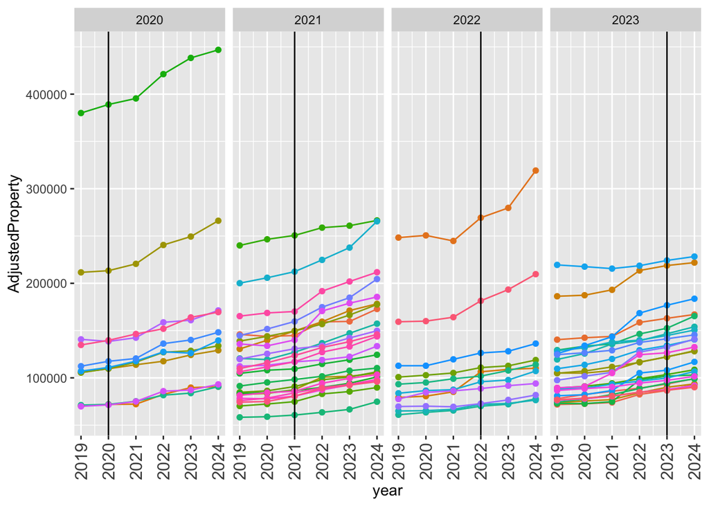

```r
##Overlaid Graphs
TiersDF %>%
  filter(LatestReval >2019) %>%
  ggplot(aes(year, AdjustedProperty, color = COUNTY))+
  geom_line()+
  geom_point()+
  facet_wrap(~LatestReval, nrow = 1)+
  theme(legend.position="none")+
  geom_vline(data = filter(TiersDF, LatestReval >2019), aes(xintercept = LatestReval))+
  theme(axis.text.x = element_text(angle = 90, vjust = 0.5, hjust=1, size = 12))
```

## Each Reval Year’s Counties Side by Side with Revaluation Year Marked

### 2020

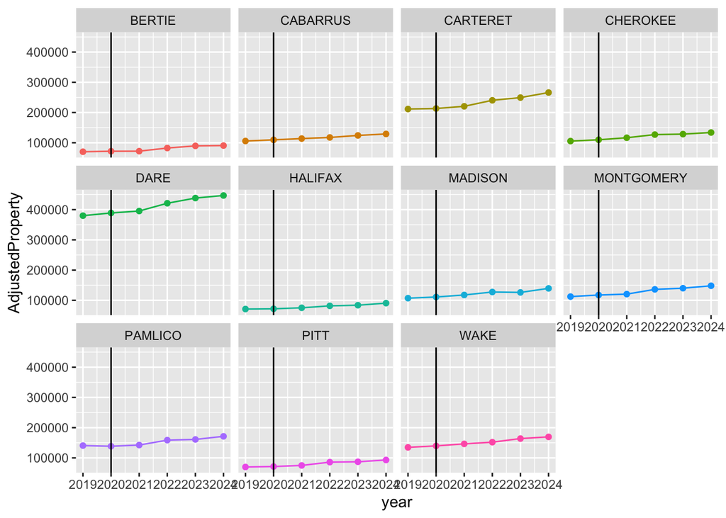

```r
TiersDF %>%
  filter(LatestReval == 2020) %>%
  ggplot(aes(year, AdjustedProperty, color = COUNTY))+
  geom_line()+
  geom_point()+
  facet_wrap(~COUNTY)+
  theme(legend.position="none")+
  geom_vline(data = filter(TiersDF, LatestReval == 2020), aes(xintercept = LatestReval))
```

### 2021

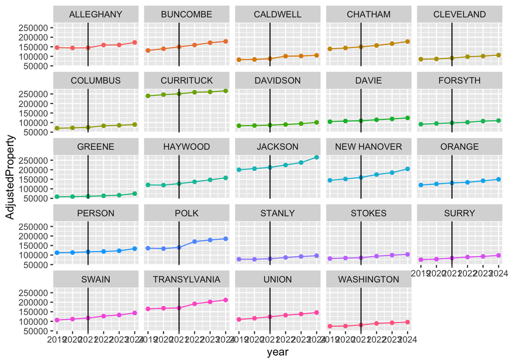

```r
TiersDF %>%
  filter(LatestReval == 2021) %>%
  ggplot(aes(year, AdjustedProperty, color = COUNTY))+
  geom_line()+
  geom_point()+
  facet_wrap(~COUNTY)+
  theme(legend.position="none")+
  geom_vline(data = filter(TiersDF, LatestReval == 2021), aes(xintercept = LatestReval))
```

### 2022

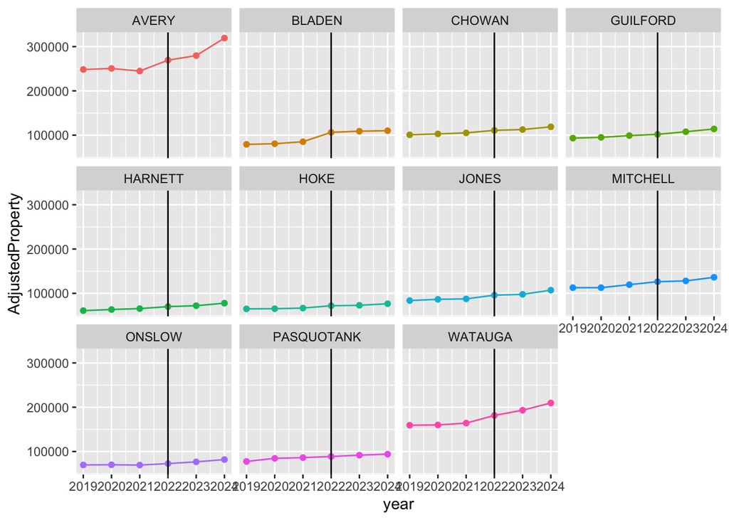

```r
TiersDF %>%
  filter(LatestReval == 2022) %>%
  ggplot(aes(year, AdjustedProperty, color = COUNTY))+
  geom_line()+
  geom_point()+
  facet_wrap(~COUNTY)+
  theme(legend.position="none")+
  geom_vline(data = filter(TiersDF, LatestReval == 2022), aes(xintercept = LatestReval))
```

### 2023

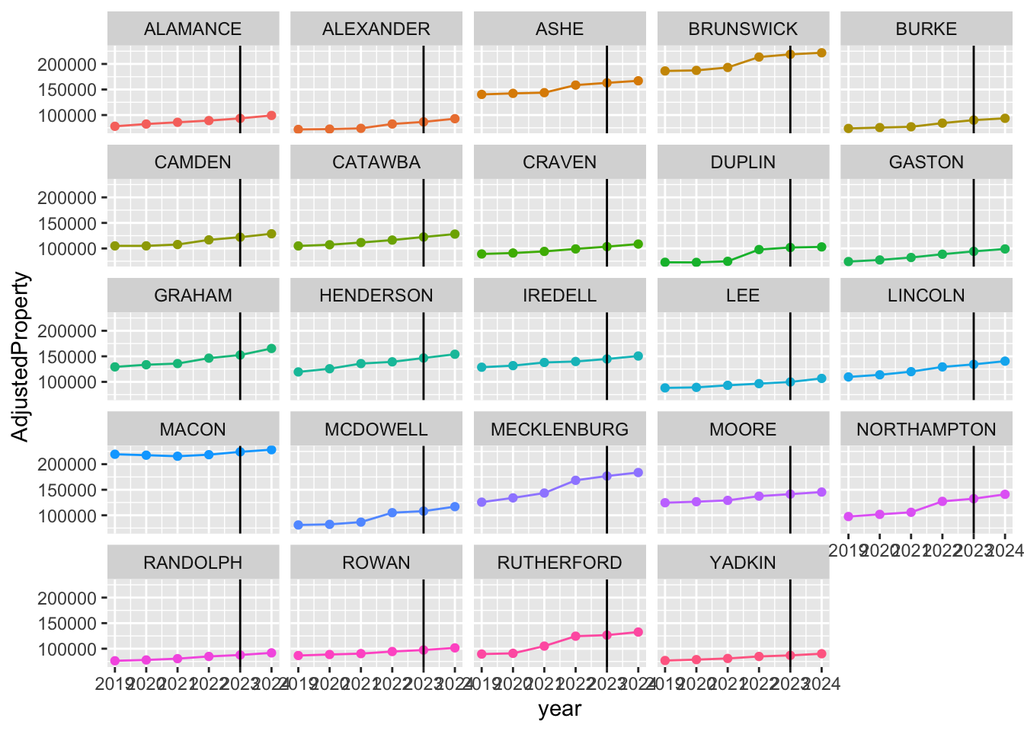

```r
TiersDF %>%
  filter(LatestReval == 2023) %>%
  ggplot(aes(year, AdjustedProperty, color = COUNTY))+
  geom_line()+
  geom_point()+
  facet_wrap(~COUNTY)+
  theme(legend.position="none")+
  geom_vline(data = filter(TiersDF, LatestReval == 2023), aes(xintercept = LatestReval))
```

### The takeaway is that the occurance of a Revaluation does not neccessarily Predict a Jump

1. Next I will determine how many of the counties who have had a revaluation since 2019 have experience a jump greater than the average jump for 6 years
- Of those that have, to what degree?
2. Find ordinary variance in County Prop Rank year to year, vs. variance in County Prop Rank on reval years.
- to contextually point 2, find ordinary variance in other 3 rankings

```r
##creating new DF with diffPropRank
ChangeinPropRank <-  TiersDF %>%
  group_by(COUNTY) %>%
  arrange(year) %>%
  reframe(diff(PropRank))
ChangeinPropRank <- select(ChangeinPropRank, "diff(PropRank)")
colnames(ChangeinPropRank) <- "diffPropRank"

Changeable <- TiersDF %>%
  filter(year != 2019) %>%
  group_by(COUNTY) %>%
  arrange(year) %>%
  arrange(COUNTY)


##this is same but for total y-o-y value change
ChangeinPropVal <-  TiersDF %>%
  group_by(COUNTY) %>%
  arrange(year) %>%
  reframe(diff(AdjustedProperty))
ChangeinPropVal <- select(ChangeinPropVal, "diff(AdjustedProperty)")
colnames(ChangeinPropVal) <- "diffPropVal"

ChangedPropRank <- bind_cols(ChangeinPropRank, ChangeinPropVal, Changeable)
```

We can calculate the year over year difference in Property Value Ranking, and view this against the reval year.

This should show us if one is more likely to move up the ranks if they have a reval year

Here is what is Property Difference looks like with a sample county (Burke of course), compared against the reval year.

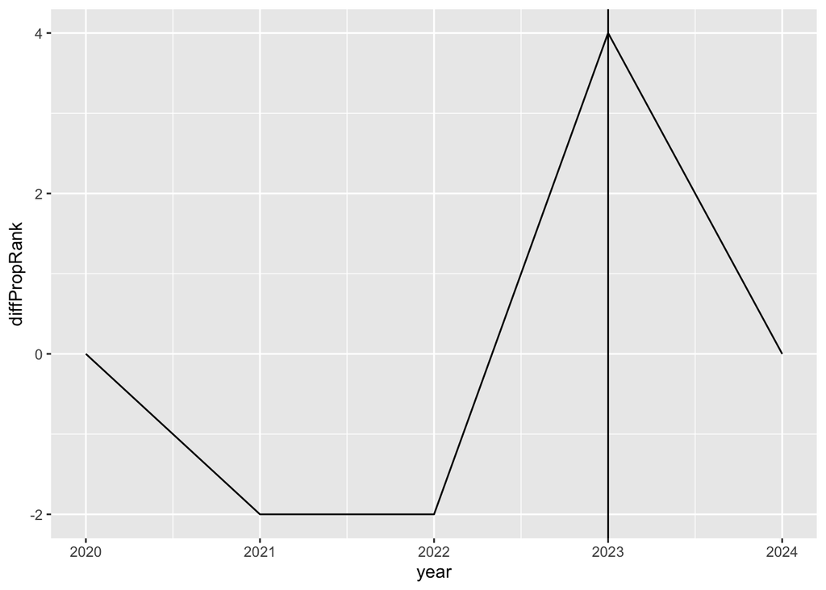

```r
##What it Shows
ChangedPropRank %>%
  filter(COUNTY == "BURKE") %>%
  ggplot(aes(year, diffPropRank))+
  geom_line()+
  geom_vline(xintercept = 2023)
```

That is a significant Jump! Lets zoom out and see the trends more generally

Below is the Average year-to-year rank change when one has a revaluation; and below that is the aveerage year-to-year rank change when one does not have a revaluation

```r
##This is big
avechangeonrevalyear <- ChangedPropRank %>%
  filter(LatestReval == year)
mean(avechangeonrevalyear$diffPropRank)
```

```
## [1] 0.08571429
```

```r
avechangenotreval <- ChangedPropRank %>%
  filter(LatestReval != year)
mean(avechangenotreval$diffPropRank)
```

```
## [1] -0.01395349
```

```r
###interesting
```

This tell us that on average a county moves up 0.08 ranks when revaluating; and they move down 0.01 ranks when not revaluating

It is now apparent there is a correlation between rankings and revaluations, but it is slight

Here is some further information on year-over-year change in Property Value Rankings

```r
quantile(avechangenotreval$diffPropRank)
```

```
##   0%  25%  50%  75% 100%
##  -23   -2    0    1   28
```

```r
quantile(avechangeonrevalyear$diffPropRank)
```

```
##   0%  25%  50%  75% 100%
##  -11   -1    0    1   14
```

The following graph, showing year over year Property Value Rank Change, overlaying each revaluation year, again shows that this correlation is not very large and not visually observable

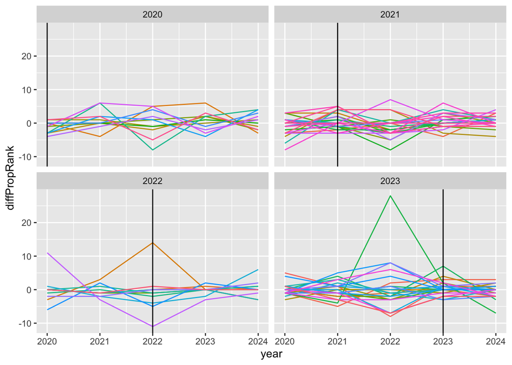

```r
ChangedPropRank %>%
  filter(LatestReval > 2019) %>%
  ggplot(aes(year, diffPropRank, color = COUNTY))+
  facet_wrap(~LatestReval)+
  geom_line()+
  geom_vline(aes(xintercept = `LatestReval`))+
  theme(legend.position="none")
```

Same scheme with total change in value

```r
mean(avechangeonrevalyear$diffPropVal)
```

```
## [1] 5088.443
```

```r
mean(avechangenotreval$diffPropVal)
```

```
## [1] 5501.516
```

```r
quantile(avechangeonrevalyear$diffPropVal)
```

```
##      0%     25%     50%     75%    100%
## -2179.0  2882.5  4500.0  5677.5 24568.0
```

```r
quantile(avechangenotreval$diffPropVal)
```

```
##         0%        25%        50%        75%       100%
## -183149.00    2016.25    4184.00    7327.00  237342.00
```

The outlier here is quite apparent. Further Research Q: Find out what happened in Hyde County

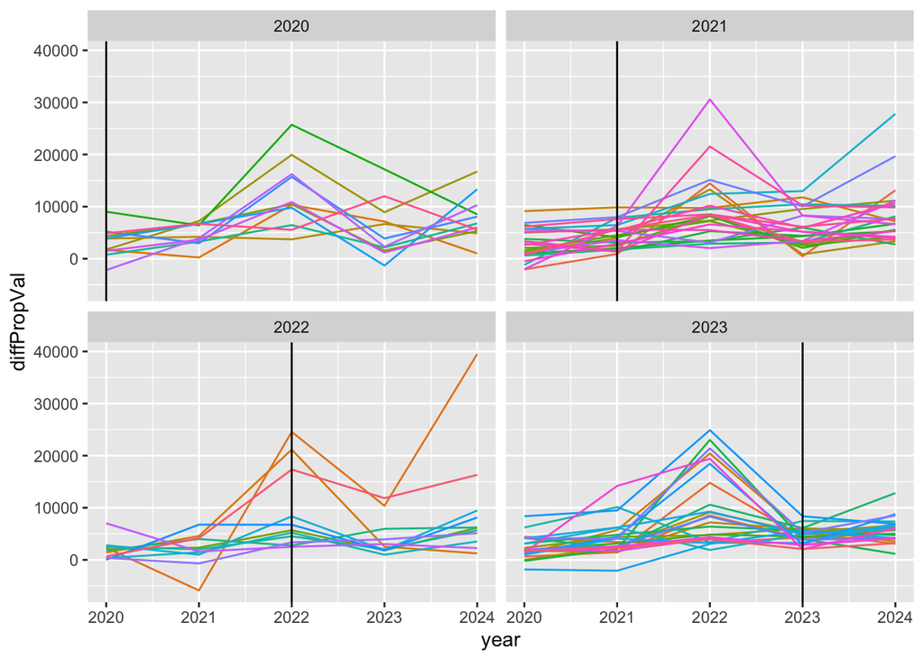

```r
ChangedPropRank %>%
  filter(LatestReval > 2019) %>%
  ggplot(aes(year, diffPropVal, color = COUNTY))+
  facet_wrap(~LatestReval)+
  geom_line()+
  geom_vline(aes(xintercept = `LatestReval`))+
  theme(legend.position="none")
```